# Pertemuan 4 - Latihan

Indra Mahib Zuhair Riyanto

## Libs

```r
library(TSA)
library(dplyr)
library(tseries)
```

## nomor 1

### manual MA(2)

```r
set.seed(6969)
wn <- rnorm(300)
ma2 <- wn[1:2]
for(i in 3:300){
   ma2[i] <- wn[i] - (0.4 * wn[i - 1]) - (0.6  * wn[i - 2])
}
ma2
```

```
##   [1]  0.277492159  0.630330212 -1.015796293 -2.151335222  1.050096636
##   [6]  0.941939235  0.192281137  1.326861753 -2.502065673  0.850044520
##  [11] -0.308752860 -3.120592320  2.062521846  2.442354984  0.529463480
##  [16] -0.065895709 -0.767833807 -2.079598865  1.269020327  2.100116371
##  [21]  0.104121968 -0.884987361  0.120921124  0.107650405 -0.833900564
##  [26] -0.511297230  0.766354575  0.482557809 -0.003281453 -0.696905774
##  [31] -0.407152397 -0.710624281 -0.666478927  1.725200110  0.514140832
##  [36] -1.024017763 -0.301317560  0.559126618 -1.560019217  0.822644104
##  [41]  1.893940418 -0.675126868 -0.154803630  1.661935851 -1.095182294
##  [46]  0.405106510  1.304848709 -1.994087214 -0.617443655 -0.073050256
##  [51] -0.403791263  0.356667232 -0.569430407  1.037627862  1.076654660
##  [56] -2.248308151  1.368738432  0.210850656 -0.365898862 -2.309435705
##  [61] -0.875881466  3.412378984 -0.722152573 -0.330821382  0.424946756
##  [66]  0.271690346  0.619617377 -0.778149232  1.208494040  0.942970728
##  [71] -1.806099454 -0.375030352  1.882369059 -1.668343416 -1.378228580
```

[output cut: 45 more lines]

### arima.sim MA(2)

```r
ma2.matic <- arima.sim(n = 300,list(order=c(0,0,2),ma=c(0.4,0.6)))
ma2.matic
```

```
## Time Series:
## Start = 1
## End = 300
## Frequency = 1
##   [1]  1.304923915 -0.774765803 -1.482272799 -1.457293031 -1.259830157
##   [6] -1.136348584 -0.840609622  0.933375846  2.768712283  1.663849116
##  [11]  1.572603615 -0.018234997  1.708424360  0.611905514  0.397382753
##  [16]  0.021428194  1.339328782  0.963755337  0.714009674 -0.786021973
##  [21]  1.087602391 -0.955987480  2.036129191  0.764457775  1.325742921
##  [26]  1.368343074 -0.350340949  1.589859484  0.372918769  1.248909251
##  [31] -0.379609468  0.728431576 -0.810671327  0.465064978  0.824497222
##  [36]  0.310758468 -0.327389164 -1.422331602 -0.188419407 -0.118201086
##  [41]  0.827770493  1.207875599  0.567387956  1.134545675  1.792695080
##  [46]  0.055674968  0.400318173  1.073447626  1.594798677  1.167288157
##  [51]  2.545377110  1.946874281  1.327756395  0.200078623 -0.289991529
```

[output cut: 49 more lines]

### Plot TS

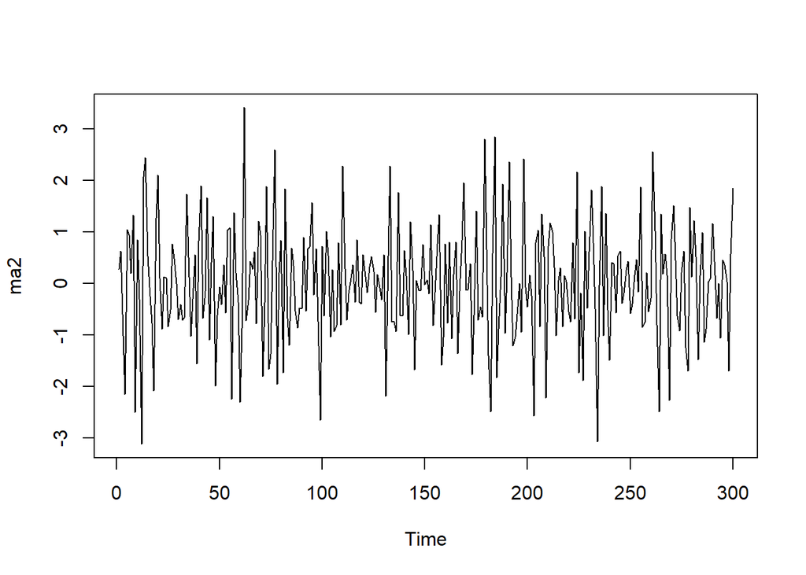

```r
plot.ts(ma2)
```

### ACF

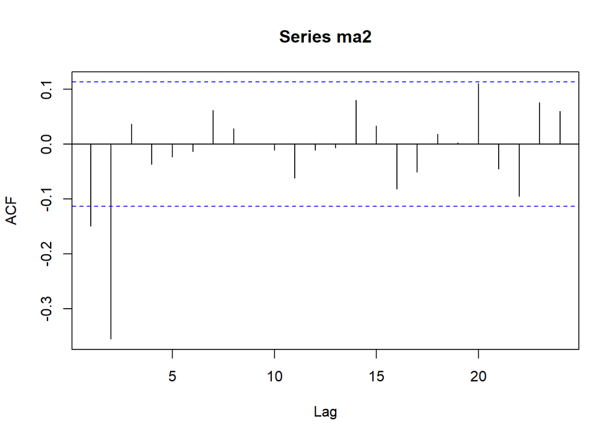

```r
acf(ma2)
```

cutoff after lag 2

### PACF

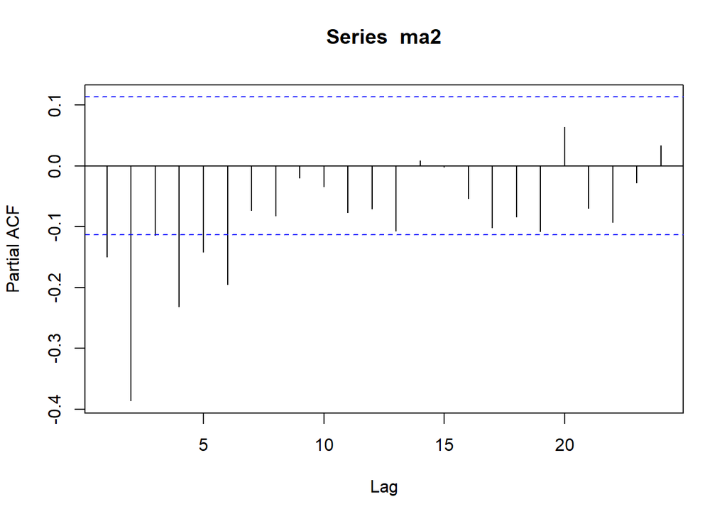

```r
pacf(ma2)
```

tail offs

### EACF

```r
TSA::eacf(ma2)
```

```
## AR/MA
##   0 1 2 3 4 5 6 7 8 9 10 11 12 13
## 0 x x o o o o o o o o o  o  o  o
## 1 x x x o o o o o o o o  o  o  o
## 2 x x x o o o o o o o o  o  o  o
## 3 x x x o x o o o o o o  o  o  o
## 4 x x o x x o o o o o o  o  o  o
## 5 x x x x x x o o o o o  o  o  o
## 6 x x x o o x o o o o o  o  o  o
## 7 x x o o x o x o o o o  o  o  o
```

segitiga dari nol pertama terlihat pada MA(2)

### Identifikasi Stasioner

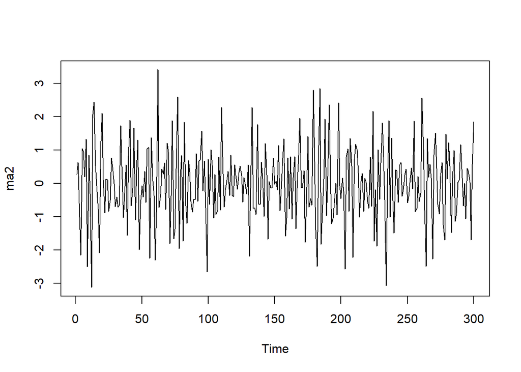

```r
plot.ts(ma2)
```

dari eksplorasi plot terlihat sepertinya stasioner. Selanjutnya kita uji dengan uji ADF.

- H0: Data tidak stasioner dalam rataan
- H1: Data stasioner dalam rataan

```r
adf.test(ma2)
```

```
##
##  Augmented Dickey-Fuller Test
##
## data:  ma2
## Dickey-Fuller = -10.658, Lag order = 6, p-value = 0.01
## alternative hypothesis: stationary
```

Menggunakan uji kita mendapatkan kesimpulan tolak H0 pada taraf 5% yang berarti data stasioner.

### Scatterplot Yt dan Yt-1

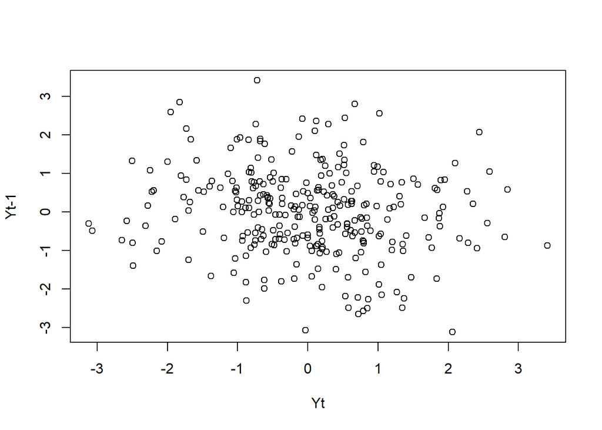

```r
plot(ma2[2:300],ma2[1:299],xlab="Yt",ylab ="Yt-1")
```

### Scatterplot Yt dan Yt-2

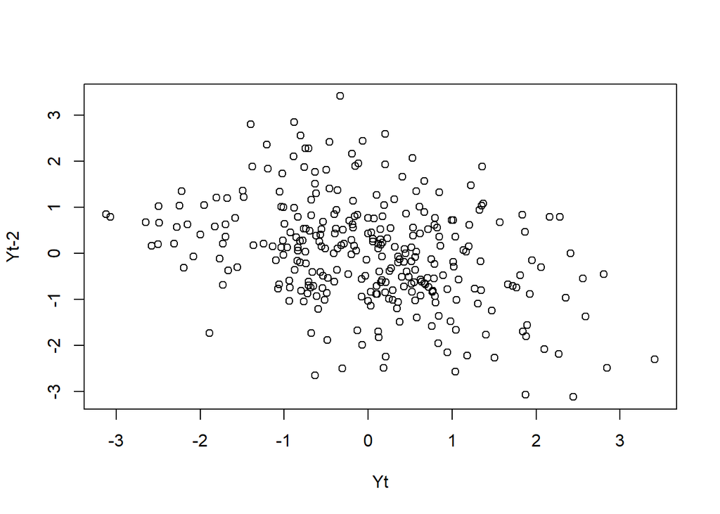

```r
plot(ma2[3:300],ma2[1:298],xlab="Yt",ylab ="Yt-2")
```

### Scatterplot Yt dan Yt-3

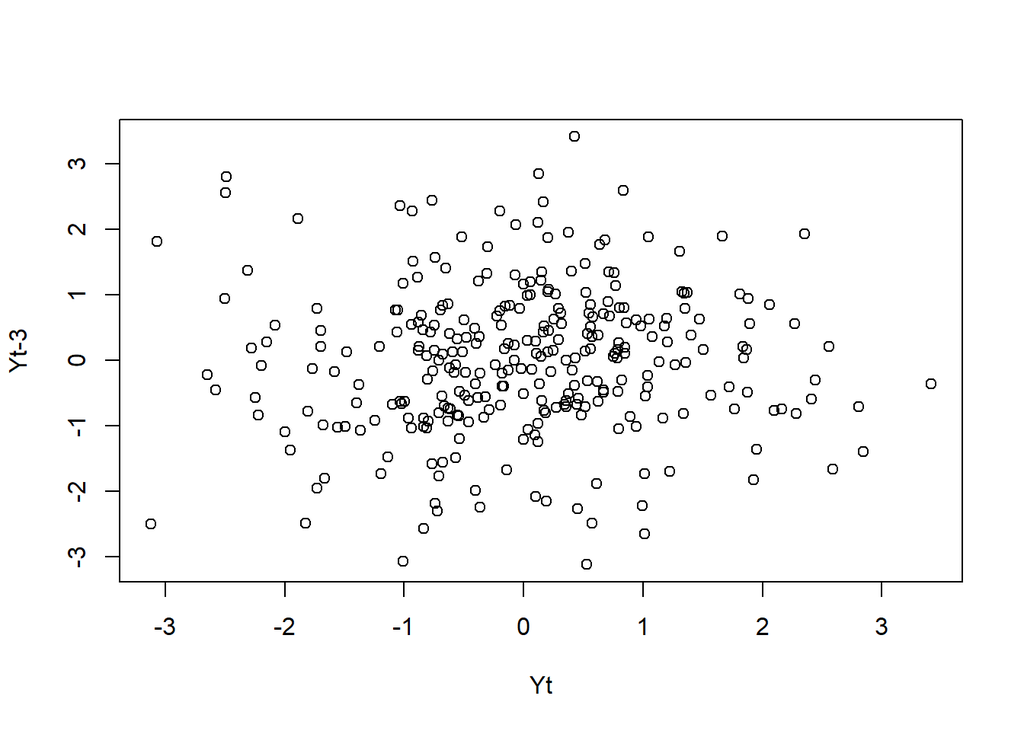

```r
plot(ma2[4:300],ma2[1:297],xlab="Yt",ylab ="Yt-3")
```

### Autokorelasi Data Vs Teoritis

```r
cor(ma2[2:300],ma2[1:299])
```

```
## [1] -0.150027
```

```r
cor(ma2[3:300],ma2[1:298])
```

```
## [1] -0.3574136
```

```r
cor(ma2[4:300],ma2[1:297])
```

```
## [1] 0.03705093
```

```r
theta1 <- 0.4
theta2 <- 0.6

ro1ma2 <- (-theta1 + (theta1 * theta2)) / (1+theta1^2+theta2^2)

ro2ma2 <- -theta2 / (1+theta1^2+theta2^2)

cat("Ro1 Data : ", cor(ma2[2:300],ma2[1:299]),"\n",
    "Ro1 Perhitungan: ", ro1ma2,"\n",
    "Ro2 Data : ", cor(ma2[3:300],ma2[1:298]),"\n",
    "Ro2 Perhitungan: ", ro2ma2, "\n",
    "Ro3 Data : ", cor(ma2[4:300],ma2[1:297]),"\n",
    "RO3 Perhitungan: ", 0)
```

```
## Ro1 Data :  -0.150027
##  Ro1 Perhitungan:  -0.1052632
##  Ro2 Data :  -0.3574136
##  Ro2 Perhitungan:  -0.3947368
##  Ro3 Data :  0.03705093
##  RO3 Perhitungan:  0
```

Terlihat dari korelasi data, nilai korelasi cukup mendekati nilai korelasi teoritis.

## Nomor 2

### Manual AR(2)

```r
n<-length(wn)
ar2 <- c()
ar2[1] <- wn[1]
ar2[2] <- wn[2]
for (i in 3:n) {ar2[i]<-wn[i]+(0.5*ar2[i-1])+(0.2*ar2[i-2])}
ar2
```

```
##   [1]  0.277492159  0.630330212 -0.226505375 -1.999191304 -1.157903302
##   [6] -1.289256102 -0.875917996  0.444888107 -1.998351459 -0.193979359
##  [11] -1.746292480 -4.102656186 -2.364129878 -1.460086952 -0.434528255
##  [16]  0.057664786 -0.138123826 -1.828980265 -0.429705435  0.661560600
##  [21]  1.153290607  0.932676243  1.452475730  1.456846606  0.855934974
##  [26]  0.469290284  0.974378017  1.140995311  1.327198632  0.755591701
##  [31]  0.518695733 -0.431698019 -1.190178386  0.107245369 -0.001643608
##  [36] -0.457078240 -0.611605975 -0.277810576 -2.003125356 -0.859595403
##  [41]  0.097390077 -0.308708136  0.192814390  1.716387139  0.670877047
##  [46]  2.002503643  2.834263377  1.297352277  1.409274790  0.656387901
##  [51]  0.199417251  0.238768805 -0.653428509  0.438258383  0.964367883
##  [56] -0.897771449  1.051238094  0.199251269  0.669599141 -1.878983618
##  [61] -2.367071291 -0.123733175 -1.620093327 -0.738180156 -0.880404220
##  [66] -0.333098100  0.266506214 -0.315017278  1.317108003  1.878056975
##  [71]  0.762142444  0.975033064  2.345469673  0.512618162  0.028439912
```

[output cut: 45 more lines]

### arima.sim AR(2)

```r
ar2.matic <- arima.sim(n = 300,list(order=c(2,0,0),ar=c(0.5,0.2)))
ar2.matic
```

```
## Time Series:
## Start = 1
## End = 300
## Frequency = 1
##   [1] -0.776869522 -0.390905678 -1.555433357 -0.133819100 -0.336467663
##   [6] -2.044977347 -1.711852423 -1.123523621  0.014908633 -1.193856559
##  [11]  1.135797854  0.772056030  1.955515550  1.099435809 -0.090853784
##  [16]  1.188173393 -0.191097190  0.266380044 -0.540576691 -0.376473583
##  [21]  0.246114784 -0.104871571 -0.417104980 -0.213291445  0.196257993
##  [26] -0.756133864 -2.414105859  0.155848871 -0.916498662 -1.743853485
##  [31] -1.110215751 -0.124572367  1.735061309 -0.199232995  1.858353025
##  [36]  0.312938075 -0.229573643 -1.010809619 -0.741243003 -0.934938511
##  [41] -0.730796313 -1.136102764  0.011341866  0.290947747 -2.357349549
##  [46]  0.687990425 -0.618184787 -0.036295007 -1.797926209 -2.236070916
##  [51] -1.736590866  0.384134654  0.577125507  1.014719997  0.703822916
```

[output cut: 49 more lines]

### Plot TS

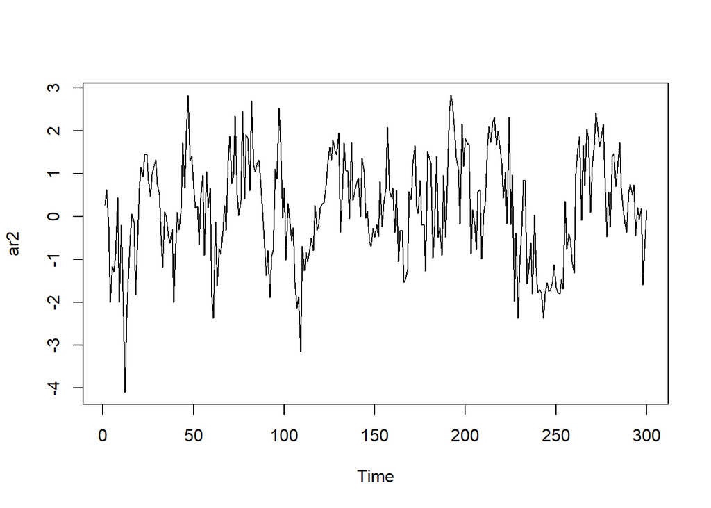

```r
plot.ts(ar2)
```

### ACF

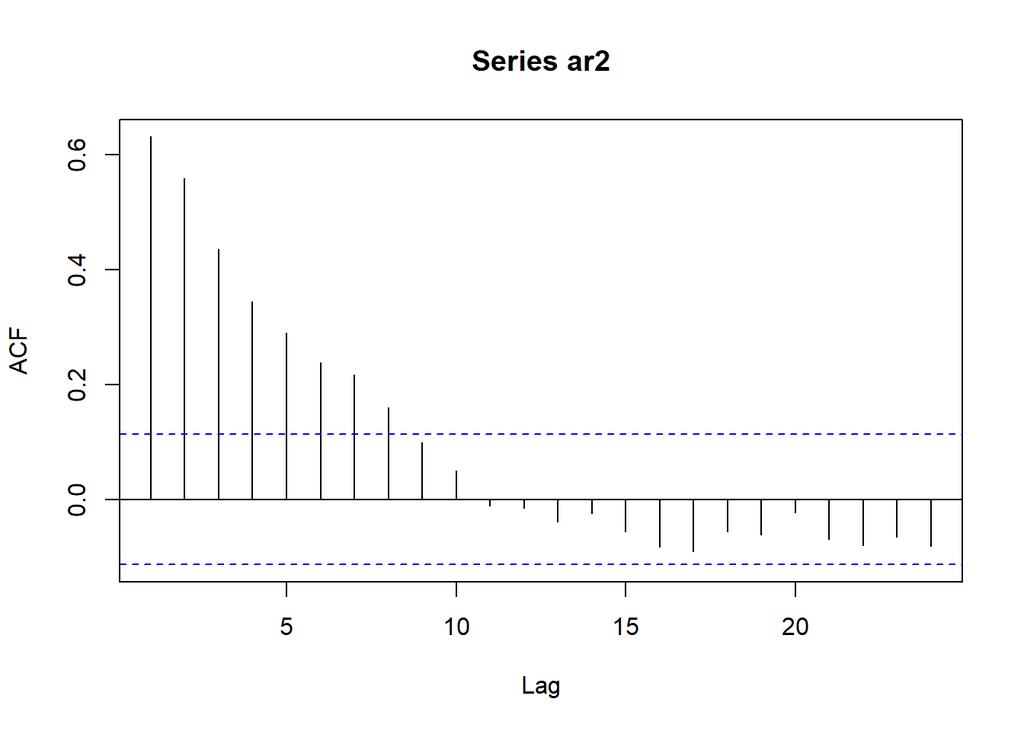

```r
acf(ar2)
```

tails off

### PACF

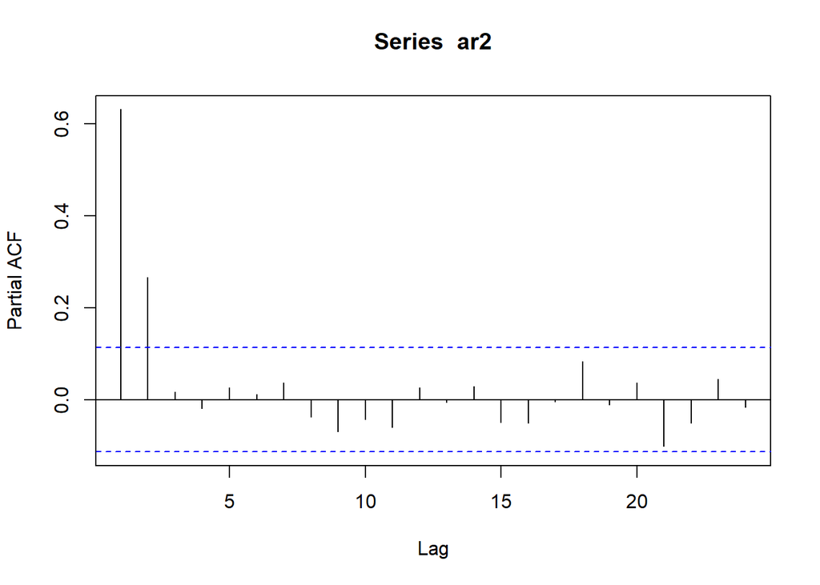

```r
pacf(ar2)
```

cut off after lag 2

### EACF

```r
TSA::eacf(ar2)
```

```
## AR/MA
##   0 1 2 3 4 5 6 7 8 9 10 11 12 13
## 0 x x x x x x x x o o o  o  o  o
## 1 x o o o o o o o o o o  o  o  o
## 2 o o o o o o o o o o o  o  o  o
## 3 x o o o o o o o o o o  o  o  o
## 4 x o o o o o o o o o o  o  o  o
## 5 x x x o o o o o o o o  o  o  o
## 6 x x x x o x o o o o o  o  o  o
## 7 x x x o x x o o o o o  o  o  o
```

segitiga dari nol terlihat pada AR(2)

### Identifikasi Stasioner

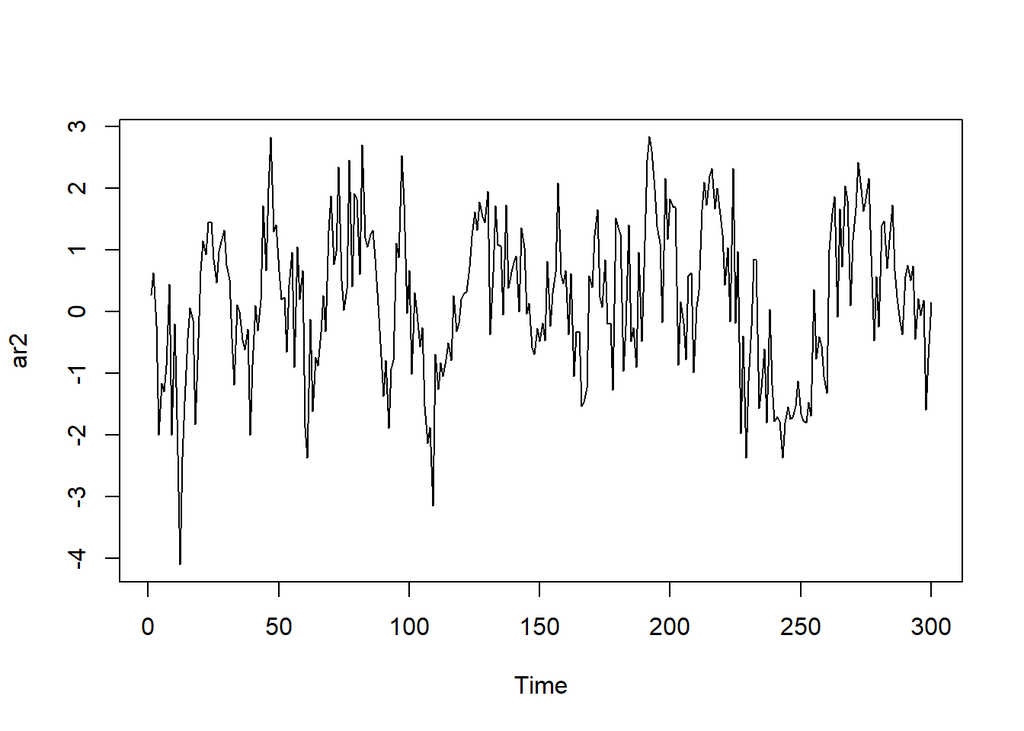

```r
plot.ts(ar2)
```

Secara eksploratif dengan plot, data terlihat stasioner. Selanjutnya kita uji dengan uji ADF.

- H0: Data tidak stasioner dalam rataan
- H1: Data stasioner dalam rataan

```r
adf.test(ar2)
```

```
##
##  Augmented Dickey-Fuller Test
##
## data:  ar2
## Dickey-Fuller = -4.1753, Lag order = 6, p-value = 0.01
## alternative hypothesis: stationary
```

Tolak H0 yang artinya, data stasioner.

### Scatterplot Yt dan Yt-1

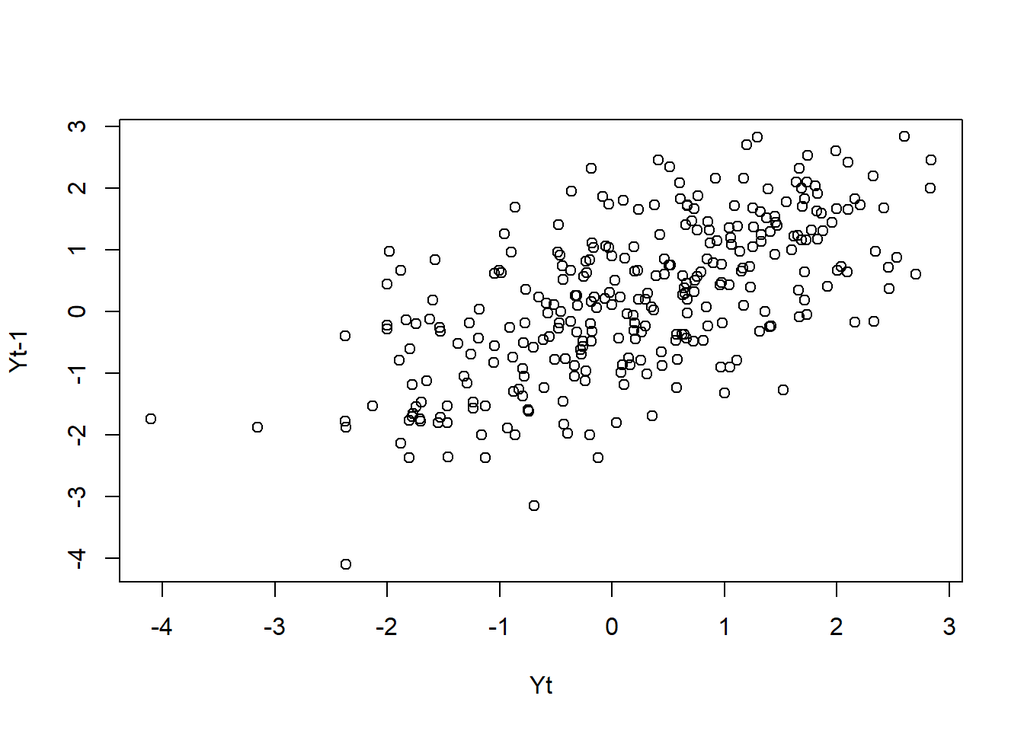

```r
plot(ar2[2:300],ar2[1:299],xlab="Yt",ylab ="Yt-1")
```

### Scatterplot Yt dan Yt-2

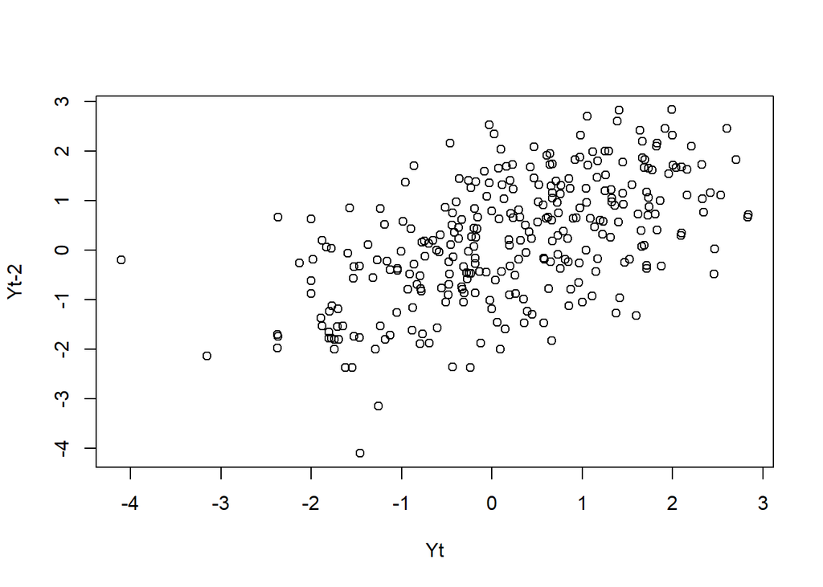

```r
plot(ar2[3:300],ar2[1:298],xlab="Yt",ylab ="Yt-2")
```

### Scatterplot Yt dan Yt-3

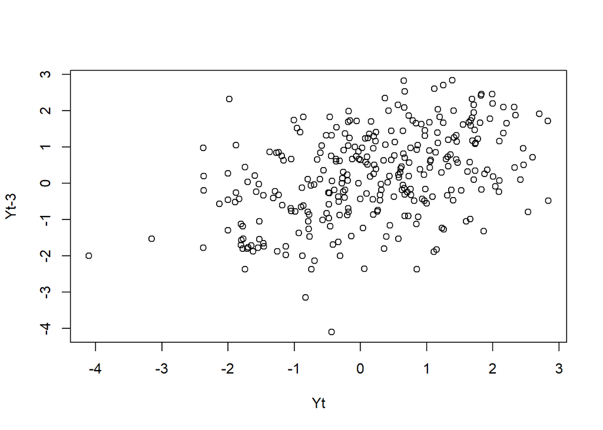

```r
plot(ar2[4:300],ar2[1:297],xlab="Yt",ylab ="Yt-3")
```

### Autokorelasi Data Vs Teoritis

```r
phi1 <- 0.5
phi2 <- 0.2
ro1ar2 <- phi1 / (1-phi2)
ro2ar2 <- (phi2*(1-phi2)+phi1^2) / (1-phi2)
ro3ar2 <- phi1 * ro1ar2 + phi2 * ro2ar2
cat(
    "Ro1 Data : ", cor(ar2[2:300],ar2[1:299]),"\n",
    "Ro1 Perhitungan: ", ro1ar2 ,"\n",
    "Ro2 Data : ", cor(ar2[3:300],ar2[1:298]),"\n",
    "Ro2 Perhitungan: ",ro2ar2 ,"\n",
    "Ro3 Data : ", cor(ar2[4:300],ar2[1:297]),"\n",
    "RO3 Perhitungan: ", ro3ar2)
```

```
## Ro1 Data :  0.6313655
##  Ro1 Perhitungan:  0.625
##  Ro2 Data :  0.5590969
##  Ro2 Perhitungan:  0.5125
##  Ro3 Data :  0.4385777
##  RO3 Perhitungan:  0.415
```

Terlihat dari korelasi data, nilai korelasi cukup mendekati nilai korelasi teoritis.

## Nomor 3

### Manual ARMA(2,2)

```r
n<-length(wn)
arma22 <- c()
arma22[1] <- wn[1]
arma22[2] <- arma22[1] * 0.5 + wn[1]*0.4 + wn[2]

for (i in 3:n) {arma22[i]<-wn[i]+(0.5*arma22[i-1])+(0.2*arma22[i-2])+(0.4*wn[i-1])+(0.6*wn[i-2])}

arma22
```

```
##   [1]  0.27749216  0.88007316  0.31699348 -1.53816273 -1.98179245 -2.86140039
##   [7] -2.01875839 -0.62712438 -2.30647202 -0.69626791 -2.99994051 -4.90005967
##  [13] -5.03962636 -4.85716165 -2.42928718 -0.98628760 -0.37126857 -1.84619556
##  [19] -1.24155289 -0.60571319  1.16161365  1.79208918  2.51840517  2.59811700
##  [25]  2.31067315  1.68616416  1.67595389  1.81254846  2.36839721  1.97120072
##  [31]  1.61735251  0.22921223 -1.05158150 -0.62780008 -0.67281841 -0.39336248
##  [37] -0.79540363 -0.79668481 -2.48120166 -1.82752311 -1.44831661 -0.78550425
##  [43]  0.12776907  1.60829098  1.47312280  3.30068847  4.03779238  3.63256081
##  [49]  3.62877449  1.99850976  1.30753773  0.71236878 -0.43827038  0.32014846
##  [55]  0.74761428 -0.24906915  1.27075033  0.08108370  1.38004256 -1.49159316
##  [61] -2.71690522 -2.19795184 -3.08982935 -1.46045738 -2.14773227 -1.12816787
##  [67] -0.39497555 -0.40827365  1.35100482  2.21588981  2.30363004  2.40672423
##  [73]  3.19276837  2.03582587  1.64076898  0.68771036  2.62996247  1.62088242
##  [79]  3.55909127  2.84019605  2.48782205  4.04215267  2.64400099  3.15591619
##  [85]  2.39386384  2.45922779  2.14676040  1.25385692  0.05129062 -1.50997442
```

[output cut: 35 more lines]

```r
arma.sim <- function(n, macoef, arcoef){
  manum <- length(macoef)
  arnum <- length(arcoef)
  stopifnot(manum < n & arnum < n)

  wn <- rnorm(n, sd = 0.5)
  init <- max(manum, arnum)

  arma <- wn[1:init]
  for(i in {init+1}:n){
   mastart <- i - manum
   maend <- i-1
   arstart <- i - arnum
   arend <- i-1
   arma[i] <- sum(arcoef * arma[arstart:arend]) + sum(macoef * wn[mastart:maend])  + wn[i]
   }
  return(arma)
}

arma22.func <- arma.sim(300, c(0.4,0.6), c(0.5,0.2))
```

### arima.sim ARMA(2,2)

```r
arma22.matic <- arima.sim(n = 300,list(order=c(2,0,2),ar=c(0.5,0.2),ma=c(0.4,0.6)))
arma22.matic
```

```
## Time Series:
## Start = 1
## End = 300
## Frequency = 1
##   [1]  0.425361148  1.073363484  3.600084043  2.866708477  2.524317516
##   [6]  1.342942376  2.223108316  2.076388295  1.747999884  3.432525023
##  [11]  1.873271640  0.229641006 -3.160500833 -3.921325913 -5.129266433
##  [16] -3.409364090 -2.295121300  0.102036285  2.172155434  2.818249279
##  [21]  2.929651207  3.294894224 -1.034821109  0.134581949 -1.096579975
##  [26]  1.375835452  1.510591535  1.698060258 -0.703832094 -0.425754429
##  [31] -1.668415146  0.082167015 -0.843226401  0.679870573  0.454008688
##  [36]  1.336646514  0.935831782  1.423269734  1.718050721  0.276352396
##  [41]  0.660896786 -0.492899553 -0.128257705 -0.514041789 -0.201622653
##  [46] -0.220284697  0.060563034 -0.642749801 -1.780888034 -4.034884353
##  [51] -4.273706139 -5.311394387 -6.153099520 -4.928797235 -4.187568215
```

[output cut: 49 more lines]

### Plot TS

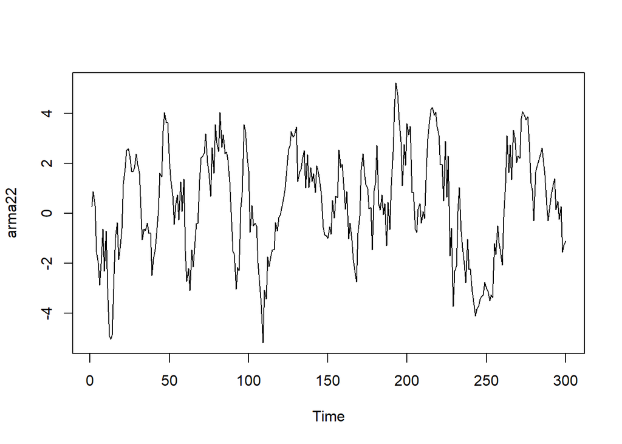

```r
plot.ts(arma22)
```

### ACF

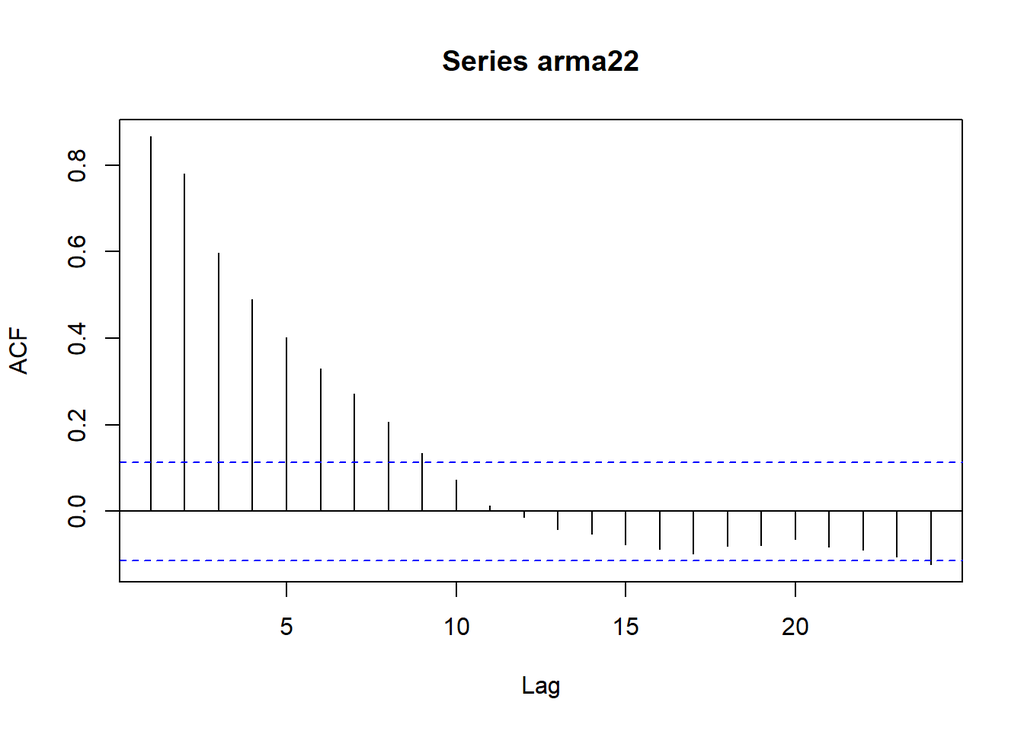

```r
acf(arma22)
```

### PACF

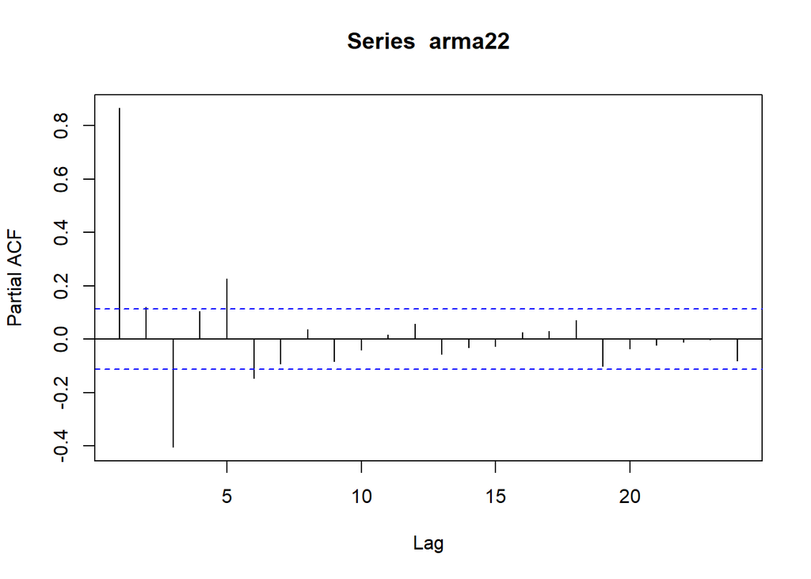

```r
pacf(arma22)
```

### EACF

```r
TSA::eacf(arma22.func)
```

```
## AR/MA
##   0 1 2 3 4 5 6 7 8 9 10 11 12 13
## 0 x x x x x x x x x x x  x  x  x
## 1 x x x x o o o o o o x  o  x  o
## 2 x x o o o o o o o o o  o  o  o
## 3 x x o o x o o o o o o  o  o  o
## 4 x x o x x o o o o o o  o  o  o
## 5 x x x x x o o o o o o  o  o  o
## 6 x x x o x x o o o o o  o  o  o
## 7 x x x x x o o o o o o  o  o  o
```

Terlihat ujung segitiga lingkaran pada ARMA(2,2)

### Identifikasi Stasioner

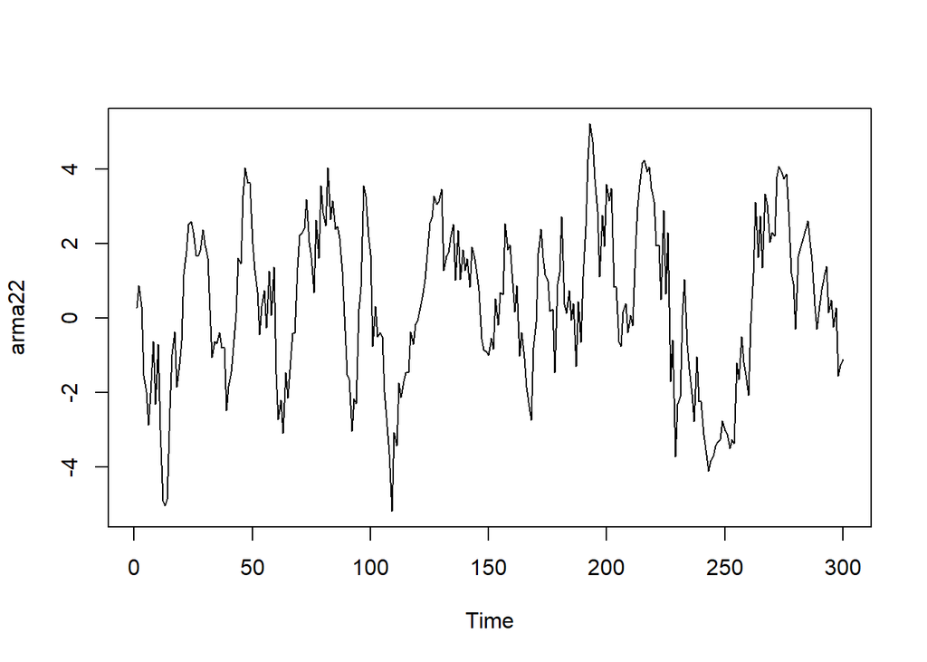

```r
plot.ts(arma22)
```

Secara eksploratif dengan plot, data terlihat stasioner. Selanjutnya kita uji dengan uji ADF.

- H0: Data tidak stasioner dalam rataan
- H1: Data stasioner dalam rataan

```r
adf.test(arma22)
```

```
##
##  Augmented Dickey-Fuller Test
##
## data:  arma22
## Dickey-Fuller = -4.5622, Lag order = 6, p-value = 0.01
## alternative hypothesis: stationary
```

Keputusannya adalah tolak H0, sehingga data stasioner.

### Scatterplot Yt dan Yt-1

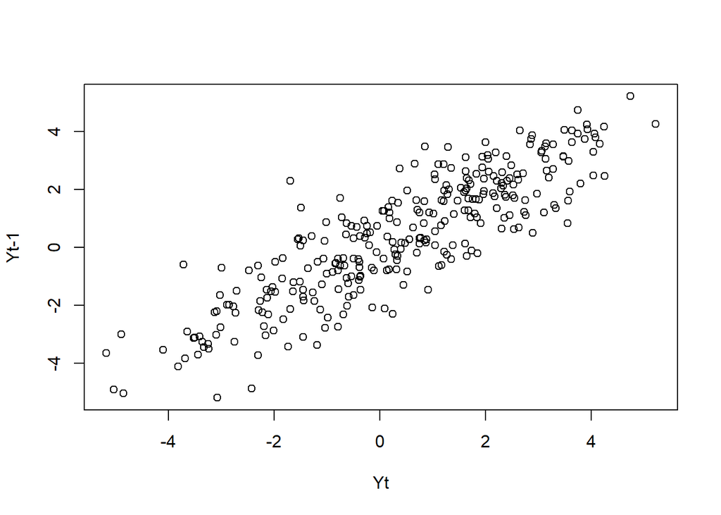

```r
plot(arma22[2:300],arma22[1:299],xlab="Yt",ylab ="Yt-1")
```

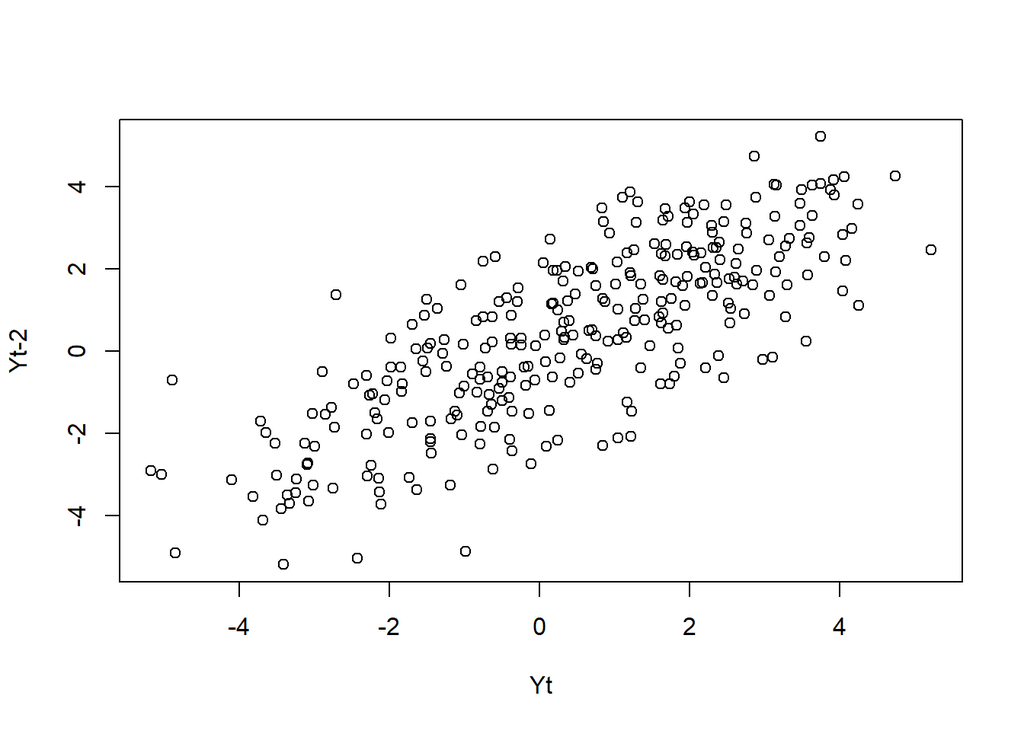

```r
plot(arma22[3:300],arma22[1:298],xlab="Yt",ylab ="Yt-2")
```

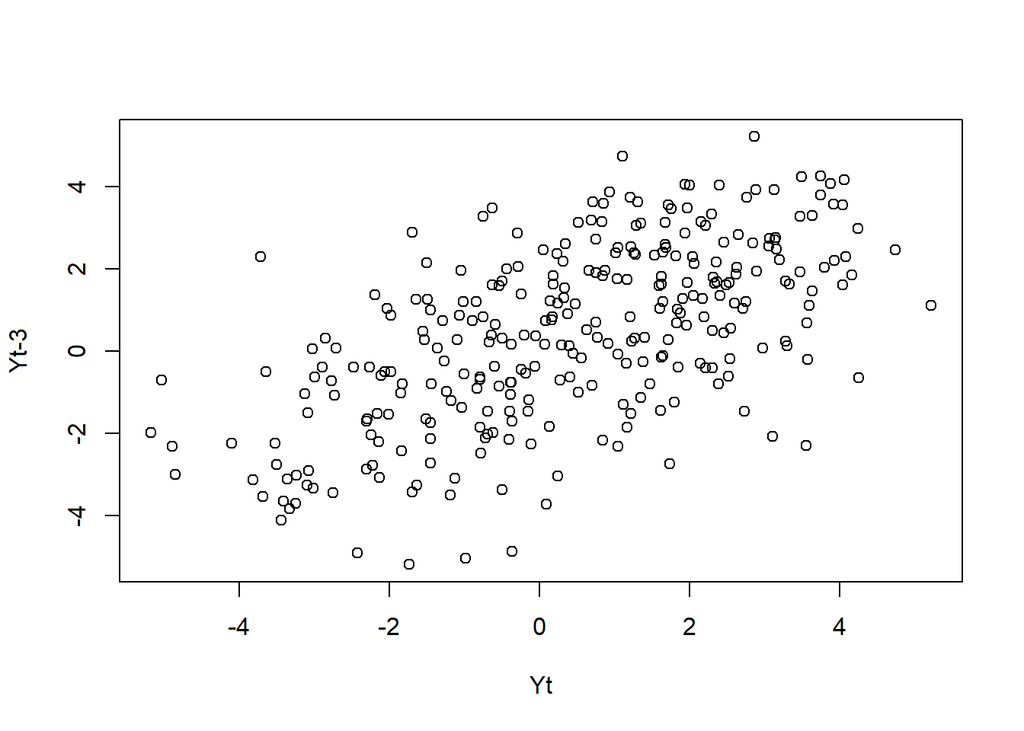

```r
plot(arma22[4:300],arma22[1:297],xlab="Yt",ylab ="Yt-3")
```

### Autokorelasi Data

```r
cor(arma22[2:300],arma22[1:299])
```

```
## [1] 0.8663904
```

```r
cor(arma22[3:300],arma22[1:298])
```

```
## [1] 0.7808332
```

```r
cor(arma22[4:300],arma22[1:297])
```

```
## [1] 0.5995457
```